# I. Exploratory Data Analysis and Quality Report

```python
# importing libraries
import os
import numpy as np
from scipy import stats
import pandas as pd
import seaborn as sns
import matplotlib.pyplot as plt
%matplotlib inline
import sklearn
from sklearn.preprocessing import StandardScaler
from sklearn.preprocessing import RobustScaler
from sklearn.preprocessing import MinMaxScaler
from sklearn.model_selection import train_test_split
import sklearn.linear_model as linear_model
from sklearn import metrics
from os import system
from sklearn.linear_model import LinearRegression #importing logistic regression
import warnings
warnings.filterwarnings('ignore')
os.getcwd()
```

```
'C:\\Users\\shubh\\Downloads\\AIML\\Data'
```

```
(1030, 9)
False
<class 'pandas.core.frame.DataFrame'>
RangeIndex: 1030 entries, 0 to 1029
Data columns (total 9 columns):
 #   Column        Non-Null Count  Dtype
---  ------        --------------  -----
 0   cement        1030 non-null   float64
 1   slag          1030 non-null   float64
 2   ash           1030 non-null   float64
 3   water         1030 non-null   float64
 4   superplastic  1030 non-null   float64
 5   coarseagg     1030 non-null   float64
 6   fineagg       1030 non-null   float64
 7   age           1030 non-null   int64
 8   strength      1030 non-null   float64
dtypes: float64(8), int64(1)
memory usage: 72.5 KB
None
               count        mean         std     min      25%      50%  \
cement        1030.0  281.167864  104.506364  102.00  192.375  272.900
slag          1030.0   73.895825   86.279342    0.00    0.000   22.000
ash           1030.0   54.188350   63.997004    0.00    0.000    0.000
water         1030.0  181.567282   21.354219  121.80  164.900  185.000
superplastic  1030.0    6.204660    5.973841    0.00    0.000    6.400
coarseagg     1030.0  972.918932   77.753954  801.00  932.000  968.000
fineagg       1030.0  773.580485   80.175980  594.00  730.950  779.500
age           1030.0   45.662136   63.169912    1.00    7.000   28.000
strength      1030.0   35.817961   16.705742    2.33   23.710   34.445

                   75%     max
cement         350.000   540.0
slag           142.950   359.4
ash            118.300   200.1
water          192.000   247.0
superplastic    10.200    32.2
coarseagg     1029.400  1145.0
fineagg        824.000   992.6
age             56.000   365.0
strength        46.135    82.6
```

[output cut: 11 more lines]

```
coarseagg    -0.086205 -0.277559 -0.026468 -0.212480     -0.241721   1.000000
fineagg      -0.245375 -0.289685  0.090262 -0.444915      0.207993  -0.162187
age           0.086348 -0.042759 -0.158940  0.279284     -0.194076  -0.005264
strength      0.488283  0.103374 -0.080648 -0.269624      0.344209  -0.144717

               fineagg       age  strength
cement       -0.245375  0.086348  0.488283
slag         -0.289685 -0.042759  0.103374
ash           0.090262 -0.158940 -0.080648
water        -0.444915  0.279284 -0.269624
superplastic  0.207993 -0.194076  0.344209
coarseagg    -0.162187 -0.005264 -0.144717
fineagg       1.000000 -0.156572 -0.186448
age          -0.156572  1.000000  0.337367
strength     -0.186448  0.337367  1.000000
```

|  | cement | slag | ash | water | superplastic | coarseagg | fineagg | age | strength |
| --- | --- | --- | --- | --- | --- | --- | --- | --- | --- |
| 0 | 141.3 | 212.0 | 0.0 | 203.5 | 0.0 | 971.8 | 748.5 | 28 | 29.89 |
| 1 | 168.9 | 42.2 | 124.3 | 158.3 | 10.8 | 1080.8 | 796.2 | 14 | 23.51 |
| 2 | 250.0 | 0.0 | 95.7 | 187.4 | 5.5 | 956.9 | 861.2 | 28 | 29.22 |
| 3 | 266.0 | 114.0 | 0.0 | 228.0 | 0.0 | 932.0 | 670.0 | 28 | 45.85 |
| 4 | 154.8 | 183.4 | 0.0 | 193.3 | 9.1 | 1047.4 | 696.7 | 28 | 18.29 |

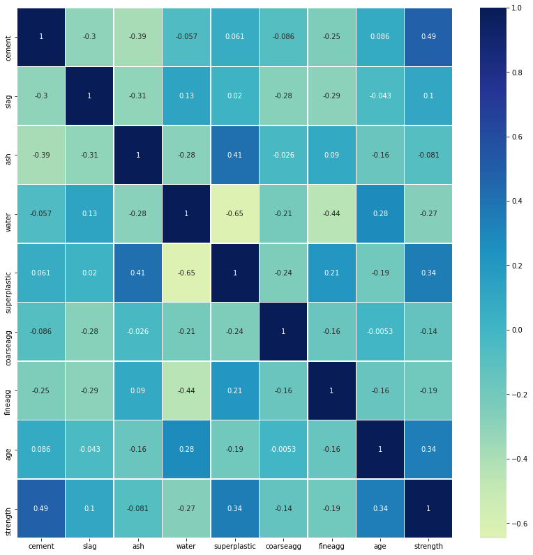

```python
# Importing data
#os.chdir('AIML/Data/')
data=pd.read_csv('../Data/concrete.csv')
columns = data.columns

# Data description
'''Data consists of ingredients of concrete (cement, fly ash etc) in kg/m3 as the independent variables'''
'''The target variable is strength (compressive) in MPa '''


# a. Univariate analysis
s1 = data.shape
print(data.shape) # Number of rows and columns in the dataframe
print(data.isnull().values.any()) # To check for null values in the dataframe
print(data.info()) # To check the data type of the columns of the dataframe
print(data.describe().T) # To review the statistical summary of the dataframe
print(data.drop_duplicates(inplace=True)) # To drop duplicate rows in the dataframe
s2 = data.shape
print(data.shape) # To print shape after dropping duplicates
if s1[0]-s2[0]>1:
    print('Duplicates have been dropped')
else:
    print('No duplicates found')


# b. Bivariate analysis
print('Bivariate analysis\n')
corr = data.corr() # Correlation matrix
print(corr)
fig, ax = plt.subplots(figsize=(14, 14))
sns.heatmap(corr, annot=True, linewidths=.5, center=0, cbar=True, cmap="YlGnBu")
data.head()
```

#### 2. It can be observed that the strength of concrete is more co-related (positively) with the amount of cement, superplastic and age as compared to other numerical variables. No features need to be dropped.

```
cement          0.564959
slag            0.855225
ash             0.497231
water           0.034433
superplastic    0.980604
coarseagg      -0.065256
fineagg        -0.252353
age             3.253974
strength        0.395696
dtype: float64
```

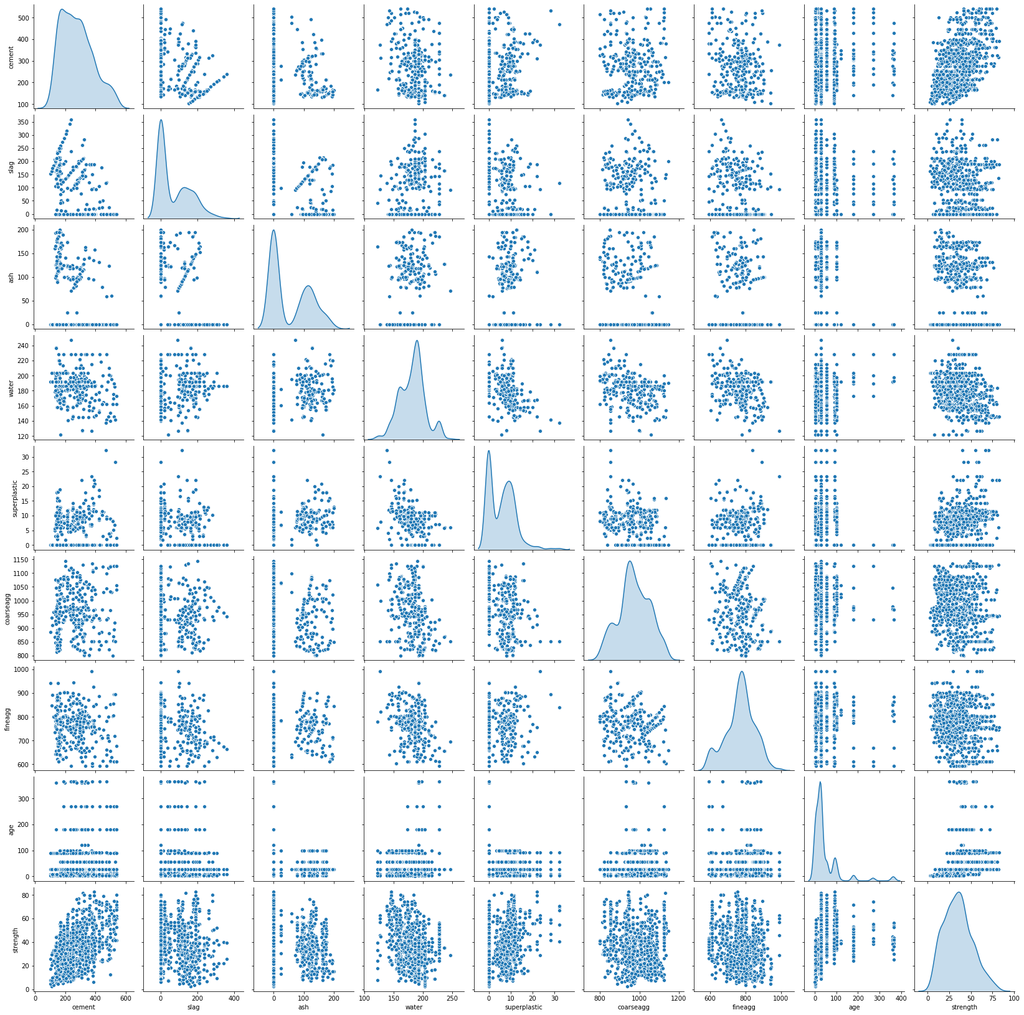

```python
# View distribution of numerical variables
print(data.skew())
skew = data.skew()
sns.pairplot(data, diag_kind='kde')
```

#### Insight: All the numerical variables do not show acute skewness. The age variable is comparitively more skewed (positive) than other variables

```
(956, 9)
```

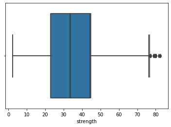

```python
# Removing outliers from the data
sns.boxplot(data['strength'])
data_filt = data[(np.abs(stats.zscore(data)) < 3).all(axis=1)]
sns.boxplot(data_filt['strength']) # change column name to plot a box plot
print(data_filt.shape)
```

#### Scaling entire data with minmaxscaler

```python
scaler = MinMaxScaler()
columns_new = data.columns
data_filt[columns_new] = scaler.fit_transform(data_filt[columns_new].to_numpy())
data_filt.head()
```

|  | cement | slag | ash | water | superplastic | coarseagg | fineagg | age | strength |
| --- | --- | --- | --- | --- | --- | --- | --- | --- | --- |
| 0 | 0.089726 | 0.670674 | 0.000000 | 0.709201 | 0.000000 | 0.496512 | 0.387607 | 0.150838 | 0.343341 |
| 1 | 0.152740 | 0.133502 | 0.621189 | 0.316840 | 0.461538 | 0.813372 | 0.507275 | 0.072626 | 0.263859 |
| 2 | 0.337900 | 0.000000 | 0.478261 | 0.569444 | 0.235043 | 0.453198 | 0.670346 | 0.150838 | 0.334994 |
| 3 | 0.374429 | 0.360645 | 0.000000 | 0.921875 | 0.000000 | 0.380814 | 0.190667 | 0.150838 | 0.542170 |
| 4 | 0.120548 | 0.580196 | 0.000000 | 0.620660 | 0.388889 | 0.716279 | 0.257652 | 0.150838 | 0.198829 |

#### Splitting data into testing and training set

```python
X=data_filt.drop(['strength'], axis=1, inplace=False)
Y=data_filt.strength
x_train, x_test, y_train, y_test = train_test_split(X, Y, test_size=0.3, random_state=42, shuffle=True)
print(x_train.shape)
x_train
```

```
(669, 8)
```

|  | cement | slag | ash | water | superplastic | coarseagg | fineagg | age |
| --- | --- | --- | --- | --- | --- | --- | --- | --- |
| 239 | 0.769406 | 0.559949 | 0.000000 | 0.557292 | 0.474359 | 0.243895 | 0.285750 | 0.307263 |
| 339 | 0.305936 | 0.496678 | 0.000000 | 0.609375 | 0.000000 | 0.498837 | 0.389112 | 0.497207 |
| 746 | 0.148402 | 0.238532 | 0.834583 | 0.366319 | 0.337607 | 0.599709 | 0.441796 | 0.553073 |
| 222 | 0.292237 | 0.000000 | 0.591204 | 0.639757 | 0.196581 | 0.663953 | 0.412945 | 0.553073 |
| 83 | 0.625571 | 0.000000 | 0.000000 | 0.805556 | 0.000000 | 0.588663 | 0.422479 | 0.553073 |
| ... | ... | ... | ... | ... | ... | ... | ... | ... |
| 110 | 0.673516 | 0.054413 | 0.789605 | 0.392361 | 0.888889 | 0.482558 | 0.097842 | 0.150838 |
| 286 | 0.621005 | 0.598545 | 0.000000 | 0.419271 | 0.431624 | 0.363663 | 0.408179 | 0.502793 |
| 923 | 0.474886 | 0.000000 | 0.000000 | 0.609375 | 0.000000 | 0.491279 | 0.642248 | 0.033520 |
| 461 | 0.529680 | 0.055679 | 0.789605 | 0.583333 | 0.653846 | 0.482558 | 0.097842 | 0.150838 |
| 106 | 0.121005 | 0.000000 | 0.714643 | 0.618056 | 0.384615 | 0.220930 | 0.687406 | 0.150838 |

669 rows × 8 columns

```
Simple linear regression score:  0.7048774126367535
Mean squared error LR:  0.012658636745384743
Test Variance score LR: 0.66
Polynomial regression: 0.9440124857409574
Mean squared error PR:  0.005309894814151293
Test Variance score PR: 0.86
```

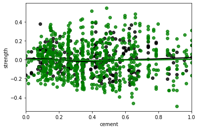

```python
from sklearn.preprocessing import PolynomialFeatures
from sklearn.metrics import mean_squared_error, r2_score
# simple linear regression degree 1
lr = LinearRegression()
lr.fit(x_train, y_train)
y_pred = lr.predict(x_test)
print('Simple linear regression score: ', lr.score(x_train, y_train))
sns.residplot(x_test['cement'], y_pred, color='black', lowess=True)
sns.residplot(x_train['cement'], y_train, color='green', lowess=True)
# The mean squared error:linear regression
print('Mean squared error LR: ', mean_squared_error(y_test, y_pred))
# Explained variance score: 1 is perfect prediction
print('Test Variance score LR: %.2f'% r2_score(y_test, y_pred))

# polynomial regression
poly = PolynomialFeatures( degree = 3, include_bias = False)
xpoly_train = poly.fit_transform(x_train)
lr_poly = lr.fit(xpoly_train, y_train)
xpoly_test = poly.fit_transform(x_test)
ypred_poly = lr.predict(xpoly_test)
print('Polynomial regression:', lr_poly.score(xpoly_train, y_train))
# The mean squared error:polynomial regression
print('Mean squared error PR: ', mean_squared_error(y_test, ypred_poly))
# Explained variance score: 1 is perfect prediction
print('Test Variance score PR: %.2f'% r2_score(y_test, ypred_poly))
```

```
(669, 164)
```

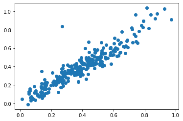

```python
plt.scatter(y_test, ypred_poly)
xpoly_train.shape
#x_test.shape
```

#### Insight: A higher degree regression model gives a better training score than a simple linear regression model. Also it has a lower mean squared error and a higher variance score. A variance score of 1 establishes that it is a perfect fit.

### Feature Selection

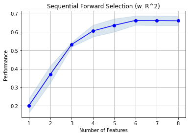

```python
from mlxtend.feature_selection import SequentialFeatureSelector as sfs
xf = data_filt.drop(['strength'], axis =1)
yf = data_filt['strength']
xf_train, xf_test, yf_train, yf_test = train_test_split(xf, yf, test_size=0.30, random_state=1)
sfs1 = sfs(lr_poly, k_features=8, forward=True, scoring='r2', cv=5)
sfs1 = sfs1.fit(xf_train.values, yf_train.values)
sfs1.get_metric_dict()

from mlxtend.plotting import plot_sequential_feature_selection as plot_sfs
fig = plot_sfs(sfs1.get_metric_dict())

plt.title('Sequential Forward Selection (w. R^2)')
plt.grid()
plt.show()
```

```python
columnList = list(xf_train.columns)
feat_cols = list(sfs1.k_feature_idx_)
print(feat_cols)
```

```
[0, 1, 2, 3, 4, 5, 6, 7]
```

```python
subsetColumnList = [columns[i] for i in feat_cols]
print(subsetColumnList)
```

```
['cement', 'slag', 'ash', 'water', 'superplastic', 'coarseagg', 'fineagg', 'age']
```

```python
xfpoly_train = poly.fit_transform(xf_train[subsetColumnList])
lr_poly = lr.fit(xfpoly_train, yf_train)
print('Regression score:', lr_poly.score(xfpoly_train, yf_train))
```

```
Regression score: 0.9438572302125308
```

# II. Creating and tuning the model

```
Mean squared error DT:  0.007679389150194152
Regression score on test data: 0.79
```

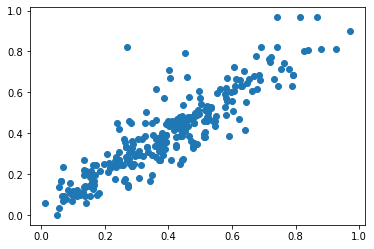

```python
from sklearn.tree import DecisionTreeRegressor

# creating regressor object
dtr = DecisionTreeRegressor(random_state = 42)
# fit the regressor with X and Y data
dtr.fit(xpoly_train, y_train)
dtr.score(xpoly_train, y_train)
ydtr_pred = dtr.predict(xpoly_test)

# The mean squared error
print('Mean squared error DT: ', mean_squared_error(y_test, ydtr_pred))
# Explained variance score: 1 is perfect prediction
print('Regression score on test data: %.2f'% r2_score(y_test, ydtr_pred))
plt.scatter(y_test, ydtr_pred)
```

### K-fold cross validation

```python
# K-fold validation has to be performed on the training data (modified with a polynomial fit)
from sklearn import model_selection
from sklearn.svm import SVR
from sklearn.ensemble import BaggingRegressor
from sklearn.ensemble import GradientBoostingRegressor
kfold = model_selection.KFold(n_splits=20)

# Model: Linear Regressor
result_lr = model_selection.cross_val_score(lr, xpoly_train, y_train, scoring='r2', cv=kfold)
result_lr_ev = model_selection.cross_val_score(lr, xpoly_train, y_train, scoring='explained_variance', cv=kfold)
print("Mean r2 Score (Linear Regressor): %.3f (%.3f)" % (result_lr.mean(), result_lr.std()))
print("Mean estimated variance score (Linear Regressor): %.3f (%.3f)" % (result_lr_ev.mean(), result_lr_ev.std()))

# Model: Decision Tree Regressor
result_dt = model_selection.cross_val_score(dtr, xpoly_train, y_train, scoring='r2',cv=kfold)
result_dt_ev = model_selection.cross_val_score(dtr, xpoly_train, y_train, scoring='explained_variance',cv=kfold)
print("Mean r2 Score (Decision Tree Regressor): %.3f (%.3f)" % (result_dt.mean(), result_dt.std()))
print("Mean estimated variance score (Decision Tree Regressor): %.3f (%.3f)" % (result_dt_ev.mean(), result_dt_ev.std()))

# Model: Bagging Regressor
br = BaggingRegressor(base_estimator=dtr, n_estimators=50, random_state=1).fit(xpoly_train, y_train)
result_br_ev = model_selection.cross_val_score(br, xpoly_train, y_train, scoring='explained_variance', cv=kfold)
result_br = model_selection.cross_val_score(br, xpoly_train, y_train, scoring='r2', cv=kfold)
print("Mean r2 Score (Bagging Regressor): %.3f (%.3f)" % (result_br.mean(), result_br.std()))
print("Mean estimated variance score (Bagging Regressor): %.3f (%.3f)" % (result_br_ev.mean(), result_br_ev.std()))

# Model: Gradient Boosting Regressor
gbr = GradientBoostingRegressor(n_estimators = 20, learning_rate = 0.1, max_depth=5 , random_state=22).fit(xpoly_train, y_train)
result_gbr_ev = model_selection.cross_val_score(gbr, xpoly_train, y_train, scoring='explained_variance', cv=kfold)
result_gbr = model_selection.cross_val_score(gbr, xpoly_train, y_train, scoring='r2', cv=kfold)
print("Mean r2 Score (Gradient Boosting Regressor): %.3f (%.3f)" % (result_gbr.mean(), result_gbr.std()))
print("Mean estimated variance score (Gradient Boosting Regressor): %.3f (%.3f)" % (result_gbr_ev.mean(), result_gbr_ev.std()))
```

```
Mean r2 Score (Linear Regressor): 0.847 (0.066)
Mean estimated variance score (Linear Regressor): 0.852 (0.062)
Mean r2 Score (Decision Tree Regressor): 0.750 (0.117)
Mean estimated variance score (Decision Tree Regressor): 0.754 (0.118)
Mean r2 Score (Bagging Regressor): 0.883 (0.036)
Mean estimated variance score (Bagging Regressor): 0.885 (0.035)
Mean r2 Score (Gradient Boosting Regressor): 0.851 (0.037)
Mean estimated variance score (Gradient Boosting Regressor): 0.855 (0.035)
```

#### Testing Gradient Boosting Regressor model without hyperparameter tuning

```python
gbr.predict(xpoly_test)
gbrscore_untuned = gbr.score(xpoly_test, y_test)
gbrscore_untuned
```

```
0.9185961761251007
```

```python
ResultsDf = pd.DataFrame({'Method':['Linear Regressor','Decision Tree','Bagging','Gradient Boosting'], 'Mean of R2':[result_lr.mean(), result_dt.mean(), result_br.mean(), result_gbr.mean()],'Mean of estimated variance score':[result_lr.std(), result_dt.std(), result_br.std(), result_gbr.std()]})
ResultsDf
```

[output not shown]

### Hyperparameter tuning

#### GridSearchCV: DecisionTreeRegressor

```python
from sklearn.tree import DecisionTreeRegressor
from sklearn.ensemble import GradientBoostingRegressor
from sklearn.model_selection import GridSearchCV
param_grid = {"criterion": ["mse"],
              "min_samples_split": [3 ,5, 10, 20, 40],
              "max_depth": [6, 8, 10, 12, 15],
              "min_samples_leaf": [2, 4, 20, 40],
              "max_leaf_nodes": [20, 100, 200, 400],
              }
grid_cv_dtm = GridSearchCV(dtr, param_grid, cv=5)

grid_cv_dtm.fit(xpoly_train, y_train)
```

```
GridSearchCV(cv=5, error_score=nan,
             estimator=DecisionTreeRegressor(ccp_alpha=0.0, criterion='mse',
                                             max_depth=None, max_features=None,
                                             max_leaf_nodes=None,
                                             min_impurity_decrease=0.0,
                                             min_impurity_split=None,
                                             min_samples_leaf=1,
                                             min_samples_split=2,
                                             min_weight_fraction_leaf=0.0,
                                             presort='deprecated',
                                             random_state=42, splitter='best'),
             iid='deprecated', n_jobs=None,
             param_grid={'criterion': ['mse'], 'max_depth': [6, 8, 10, 12, 15],
                         'max_leaf_nodes': [20, 100, 200, 400],
                         'min_samples_leaf': [2, 4, 20, 40],
                         'min_samples_split': [3, 5, 10, 20, 40]},
             pre_dispatch='2*n_jobs', refit=True, return_train_score=False,
             scoring=None, verbose=0)
```

```python
print("R-Squared::{}".format(grid_cv_dtm.best_score_))
print("Best Hyperparameters::\n{}".format(grid_cv_dtm.best_params_))
dt_new = DecisionTreeRegressor(max_depth=12, max_leaf_nodes=200, min_samples_leaf=4, min_samples_split=3,random_state = 42).fit(xpoly_train, y_train)
dt_new.predict(xpoly_test)
dt_new.score(xpoly_test, y_test)
```

```
R-Squared::0.7770252050195017
Best Hyperparameters::
{'criterion': 'mse', 'max_depth': 12, 'max_leaf_nodes': 200, 'min_samples_leaf': 4, 'min_samples_split': 3}
```

```
0.8049887662583397
```

#### GridSearchCV: Gradient Boosting Regressor

```python
param_grid = {"n_estimators":[50, 70, 100], 'learning_rate':[0.1, 0.2, 0.4]}
grid_cv_gbr = GridSearchCV(gbr, param_grid, cv=5)
grid_cv_gbr.fit(xpoly_train, y_train)
```

[output not shown]

```python
print("R-Squared::{}".format(grid_cv_gbr.best_score_))
print("Best Hyperparameters::\n{}".format(grid_cv_gbr.best_params_))
grid_cv_gbr.best_params_
```

```
R-Squared::0.8911103752662527
Best Hyperparameters::
{'learning_rate': 0.1, 'n_estimators': 100}
```

```
{'learning_rate': 0.1, 'n_estimators': 100}
```

```python
gbr = GradientBoostingRegressor(n_estimators = 120, learning_rate = 0.1, max_depth=5 , random_state=42).fit(xpoly_train, y_train)
gbr.predict(xpoly_test)
gbrscore_tuned = gbr.score(xpoly_test, y_test)
print('Tuned score for Gradient Boosting Regressor:', gbrscore_tuned)
```

```
Tuned score for Gradient Boosting Regressor: 0.9267710304281377
```

#### Dataframe for comparison of model with previous and new metrics

```python
ResultsDf_comp = pd.DataFrame({'Tuning State':['False','True'], 'R2 train':[result_gbr.mean(), grid_cv_gbr.best_score_ ] ,'R2 test':[gbrscore_untuned, gbrscore_tuned]})
ResultsDf_comp
```

|  | Tuning State | R2 train | R2 test |
| --- | --- | --- | --- |
| 0 | False | 0.851477 | 0.918596 |
| 1 | True | 0.891110 | 0.926771 |

#### Conclusion: With hyperparameter tuning, the testing regression score increases marginally as showcased for Gradient Boosting Regressor